# Traffic

Zhe Zhao(433707)

2022/5/24

## Introduction

The main target of this project is using regression methods of machine learning to build a model predicting the traffic on one of the highways for one-hourly intervals based on the training sample and generate predictions for all observations from the test sample.

```r
library(dplyr)
```

```r
library(ggplot2)
library(caret)
library(lattice)
library(corrplot)
```

## Import data

Import data and check detailed information.

```r
## read data
traffic <- read.csv("C:/Users/zhaoz/Desktop/jiqixuexi/pro/traffic_train.csv")
```

“Traffic” is the dependent variable, so we need to remove the value equal to 0 to get the MAPE value, firstly we check if there are “0”s. There are “0” values, so We have to remove these rows with “traffic” equal to 0.

```r
## 0s transform into NA
traffic$traffic[which(traffic$traffic=="0")] <- NA
## omit NA value
traffic <- na.omit(traffic)
```

```r
## 0s transform into NA
traffic$temperature[which(traffic$temperature=="-273.1")] <- NA

## omit NA value
traffic <- na.omit(traffic)
```

Set training sample as 70% and testing sample as 30%.

```r
## set training sample and test sample

set.seed(20030329) #set Random seed
traffic_which_training <- createDataPartition(traffic$traffic,
                          p = 0.7, list = FALSE)  #set 70% of data as training data

traffic_train <-traffic[c(traffic_which_training),] #training data
traffic_test <-traffic[-c(traffic_which_training),] #test data

## save data
save(list = c("traffic_train",
              "traffic_test"),
     file = "C:/Users/zhaoz/Desktop/jiqixuexi/pro/traffic_train_test.RData")
```

I chose only 3 variables: “traffic”, “date_time” and “temperature”.

```r
traffic_train_pro <- traffic_train[,c("traffic", "date_time", "temperature")]

traffic_train_pro$date_time <- as.factor(traffic_train_pro$date_time)
```

## Linear regression model

Why linear regression? 1. This modeling speed is fast, and it does not require very complicated calculations. It still runs very fast in the case of a large amount of data, especially there are almost 30,000 pieces of data. 2. It could give us an explanation for each variable in terms of coefficients.

Why not KNN(K-Nearest Neighbor) or SVR(support vector regression)? The computational complexity are high, the amount of computation are too large, so they took really long time. However, the MAPE value of LR and SVR(linear kernel) are really similar, LNN has Worse MAPE.

All in all, speed of LR is fast and lower MAPE.

```r
## Linear regression model
traffic_lm1 <- lm(traffic ~ date_time + temperature, # formula
                 data = traffic_train_pro)
## output
summary(traffic_lm1)
```

```
##
## Call:
## lm(formula = traffic ~ date_time + temperature, data = traffic_train_pro)
##
## Residuals:
##     Min      1Q  Median      3Q     Max
## -5686.0  -310.3    75.9   523.0  2713.7
##
## Coefficients:
##              Estimate Std. Error t value Pr(>|t|)
## (Intercept)  761.2706    32.6075  23.346  < 2e-16 ***
## date_time1  -284.3174    45.8355  -6.203 5.64e-10 ***
## date_time2  -409.8861    45.8888  -8.932  < 2e-16 ***
## date_time3  -432.7888    45.8082  -9.448  < 2e-16 ***
## date_time4  -113.4122    45.1660  -2.511    0.012 *
## date_time5  1192.8951    45.5414  26.194  < 2e-16 ***
## date_time6  3295.9770    45.4655  72.494  < 2e-16 ***
## date_time7  3848.3285    45.7584  84.101  < 2e-16 ***
## date_time8  3738.5066    45.3694  82.401  < 2e-16 ***
## date_time9  3530.5393    46.5569  75.833  < 2e-16 ***
## date_time10 3342.5743    45.2687  73.839  < 2e-16 ***
## date_time11 3629.5708    46.3902  78.240  < 2e-16 ***
## date_time12 3865.5062    46.2813  83.522  < 2e-16 ***
## date_time13 3879.9570    46.5716  83.312  < 2e-16 ***
## date_time14 4099.2993    45.7524  89.597  < 2e-16 ***
## date_time15 4379.2829    46.1968  94.796  < 2e-16 ***
## date_time16 4769.6657    45.8757 103.969  < 2e-16 ***
## date_time17 4436.7097    46.1674  96.101  < 2e-16 ***
## date_time18 3403.3182    46.1795  73.698  < 2e-16 ***
## date_time19 2413.0120    46.2104  52.218  < 2e-16 ***
## date_time20 1966.5167    45.9738  42.775  < 2e-16 ***
## date_time21 1827.5231    45.9942  39.734  < 2e-16 ***
## date_time22 1346.2881    46.0256  29.251  < 2e-16 ***
## date_time23  630.1230    45.4021  13.879  < 2e-16 ***
## temperature    7.1527     0.5285  13.534  < 2e-16 ***
## ---
## Signif. codes:  0 '***' 0.001 '**' 0.01 '*' 0.05 '.' 0.1 ' ' 1
##
## Residual standard error: 953.7 on 20749 degrees of freedom
## Multiple R-squared:  0.7701, Adjusted R-squared:  0.7698
## F-statistic:  2896 on 24 and 20749 DF,  p-value: < 2.2e-16
```

Residuals

```r
head(traffic_lm1$residuals)
```

```
##          1          2          3          4          5          6
## -335.52618 -227.62553 -134.60581  -12.98779  118.36458  726.49467
```

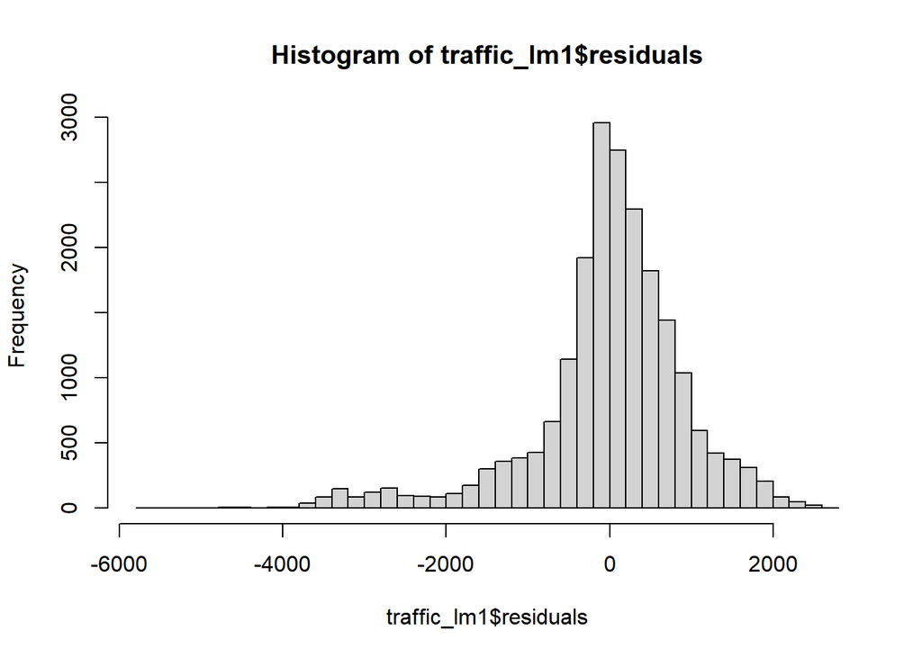

```r
hist(traffic_lm1$residuals, breaks = 30)
```

```r
# MSE is basically the average square residual

mean(traffic_lm1$residuals^2)
```

```
## [1] 908531.5
```

```r
# MAE is the average absolute residual

mean(abs(traffic_lm1$residuals))
```

```
## [1] 655.0371
```

```r
# similarly we can calculate Median Absolute Error

median(abs(traffic_lm1$residuals))
```

```
## [1] 428.1202
```

Write a simple function to summarize MSE, RMSE, MAE, MAPE, MedAE, MSLE and R2.

```r
# Write a simple function to summarize all the errors and R2

regressionMetrics <- function(real, predicted) {
  # Mean Square Error
  MSE <- mean((real - predicted)^2)
  # Root Mean Square Error
  RMSE <- sqrt(MSE)
  # Mean Absolute Error
  MAE <- mean(abs(real - predicted))

  # Mean Absolute Percentage Error!!
  MAPE <- mean(abs(real - predicted)/real)

  # Median Absolute Error
  MedAE <- median(abs(real - predicted))
  # Mean Logarithmic Absolute Error
  MSLE <- mean((log(1 + real) - log(1 + predicted))^2)
  # R2
  R2 <- cor(predicted, real)^2

  result <- data.frame(MSE, RMSE, MAE, MAPE, MedAE, MSLE, R2)
  return(result)
}

# apply it to LR model
regressionMetrics(real = traffic_train_pro$traffic,
                  predicted = predict(traffic_lm1))
```

```
##        MSE     RMSE      MAE     MAPE    MedAE      MSLE        R2
## 1 908531.5 953.1692 655.0371 1.164449 428.1202 0.1945309 0.7701107
```

R^2 = 0.7701107 and MAPE = 1.164449, seems okay, so lets check how it’s performance in testing sample. Testing sample is names “traffic_test”, separated from “traffic_train”.

```r
## Linear regression model for testing data
traffic_test$date_time <- as.factor(traffic_test$date_time)
traffic_test$predicted <- traffic_lm1 %>% predict(traffic_test)

## output
print(mean(abs(traffic_test$traffic - traffic_test$predicted)/traffic_test$traffic))
```

```
## [1] 1.053358
```

```r
print(bquote(R^2==.(R2(traffic_test$predicted,traffic_test$traffic))))
```

```
## R^2 == 0.767948620226271
```

We can check the MAPE value, it is even lower. We can also see the value of R^2 = 0.767948620226271, still high!

## Conslusion

I built SVR and KNN model also, but the results are similar or worse, so i just chose Linear Regression model. The value of R square and MAPE Linear Regression model are not very good, but they are still better than the other models I used.